# Try your data

## 1. Prepare your data

#### a) Initialize dataset as tibble of two variables

```r
set.seed(1234)
x <- rnorm(12, mean = rep(1:3, each = 4), sd = 1)
y <- rnorm(12, mean = rep(c(1, 2, 1), each = 4), sd = 1)
df_xy <- tibble(x, y)
```

#### b) Set initial coordinates of cluster`s centers and their identificators

```r
Cx = c(1, 1.6, 3.5)
Cy = c(1, 2.0, 0.6)
# Number of clusters define as length of Cx or Cy vectors
n_clust <- length(Cx)
df_cl <- tibble(Cluster = factor(seq(n_clust), ordered = T), Cx, Cy)
```

#### c) Make dataset that connect our points with initial cluster’s

```r
df_kmeans0 <- bind_cols(df_xy, map_dfr(df_cl, rep, each = length(x) / n_clust))
```

#### d) Now, take a look at the initial configuration of the clusters

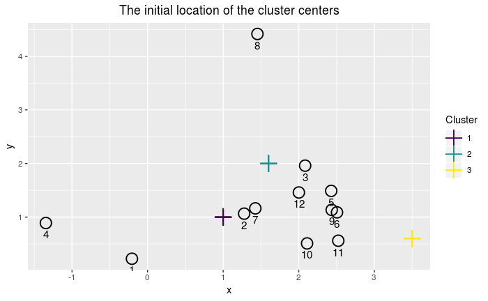

```r
ggplot(df_kmeans0, aes(x, y)) +
  geom_point(shape = 1, size = 5, stroke = 1) +
  geom_text(aes(x, y, label = rownames(df_xy)), vjust = 2.0, size = 4, color = "black") +
  geom_point(aes(Cx, Cy, color = Cluster), shape = 3, size = 5, stroke = 1) +
  labs(title = "The initial location of the cluster centers") +
  theme(plot.title = element_text(hjust = 0.5))
```

## 2. Run k-means algorithm

#### a) Get dataset with k-means iterations

```r
n_iter <- 5 # nubmer of k-means iterations
df_kmeans <- wraper_kmeans(df_xy, df_cl, n_iter)
```

#### b) View main results of k_means algorithm for chosen iteration

```r
my_kmeans <- get_kmeans(n_iter, df_kmeans)
my_kmeans
```

```
$`Cluster means`
# A tibble: 3 x 3
  Cluster     Cx    Cy
  <ord>    <dbl> <dbl>
1 1       -0.776 0.557
2 2        1.45  4.42
3 3        2.09  1.16

$`Clustering vector`
 [1] 1 3 3 1 3 3 3 2 3 3 3 3
Levels: 1 < 2 < 3

$`Within cluster sum of squares by cluster`
# A tibble: 3 x 2
  Cluster `sum(Eu_dist)`
  <ord>            <dbl>
1 1                0.870
2 2                0
3 3                3.34
```

#### c) Get result from build-in k-means() function

```r
kmeans(x = as.matrix(df_xy), centers = cbind(Cx, Cy),
       iter.max = n_iter, algorithm = "Forgy")
```

```
K-means clustering with 3 clusters of sizes 2, 1, 9

Cluster means:
           x         y
1 -0.7763817 0.5567303
2  1.4533681 4.4158352
3  2.0880269 1.1585578

Clustering vector:
 [1] 1 3 3 1 3 3 3 2 3 3 3 3

Within cluster sum of squares by cluster:
[1] 0.8699983 0.0000000 3.3412774
 (between_SS / total_SS =  85.3 %)

Available components:

[1] "cluster"      "centers"      "totss"        "withinss"     "tot.withinss" "betweenss"    "size"         "iter"
[9] "ifault"
```

## 3. Visualize results

#### a) Make “long” dataframe from the df_kmeans list

```r
df_long <- map_dfr(df_kmeans, ~ .)
```

#### b) Visualize clusters as poligons, animate points accesory to clusters (by changing color) and centers of clusters

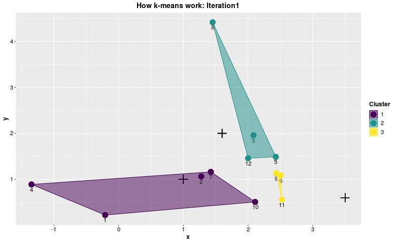

```r
theme_ani <- theme(
          plot.title = element_text(size = 14, face = "bold", hjust = 0.5),
          legend.title = element_text(face = "bold", colour = "black", size = 12),
          legend.text = element_text(size = 11, color = "black"),
          axis.text = element_text(size = 11, colour = "black"),
          axis.title = element_text(size = 12, face = "bold"))
ggplot(df_long, aes(x, y, color = Cluster, frame = Iteration)) +
  geom_point(aes(group = Cluster), size = 5) +
  geom_point(aes(x = Cx, y = Cy), shape = 3, size = 5, color = "black", stroke = 1) +
  geom_path(aes(x = Cx, y = Cy, cumulative = TRUE, group = Cluster),
            color = "black") +
  geom_text(aes(x, y, label = rowid), vjust = 1.8, size = 4, color = 'black') +
  geom_polygon(data = df_polygon(df_kmeans),
               aes(x, y, group = Cluster, fill = Cluster), alpha = .5) +
  labs(title = "How k-means work:") +
  theme_ani -> gg
gganimate(gg)
```

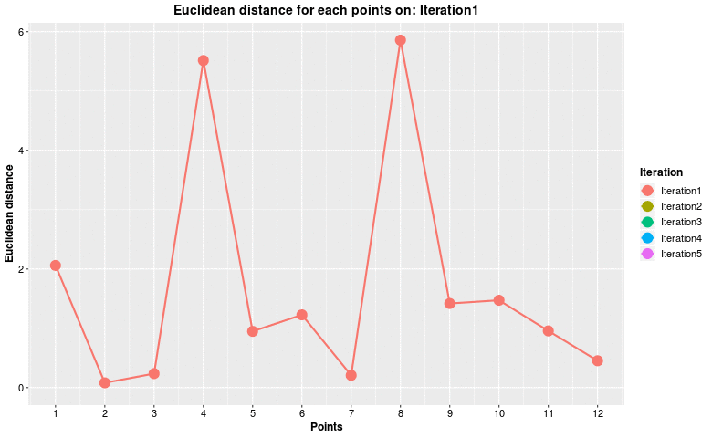

```r
ggplot(df_long, aes(x = rowid, y = Eu_dist, frame = Iteration, cumulative = TRUE)) +
  geom_point(aes(color = Iteration), size = 5) +
  geom_line(aes(color = Iteration), size = 1) +
  scale_x_continuous(breaks = 1:dim(df_xy)[1]) +
  labs(x = "Points", y = "Euclidean distance",
       title = "Euclidean distance for each points on:") +
  theme_ani -> gg_dist
gganimate(gg_dist)
```

#### **Comment#1**

By the end I want to mention some things.  
This is a demonstration example, so the k-means algorithm implemented here may be far from effective. Because of this, I do not recommend using it with large datasets and a large number of iterations (> 10). Of course, you can use your own dataset if you are interested.

#### **Comment#2**

So, what have I achieved by reinventing the wheel:  
1. Understood the [k-means](https://en.wikipedia.org/wiki/K-means_clustering) algorithm, of course)  
2. Improved my skills in [tydiverse](https://www.tidyverse.org/)  
3. Learned to write recursive functions that return two values, one of which is necessary for recursion work, and the other - for external needs. This was achieved by the additional wrapper function and the concept of environments.  
4. Learned to make animated charts with gganimate.  
5. Examined chull function from base R  
6. Learned how to [hide comments](https://stackoverflow.com/questions/4823468/comments-in-markdown) in [Rmarkdown](https://rmarkdown.rstudio.com/index.html)

I’d be appriciate for your critical remarks and comments. Well, of course I will be very-very-very happy if this material helps you understand k-means as it helped me!